# Assignment01

Group 5

#### Data Exploration and Preparation

As the quality of our inputs decide the quality of your output, we will be spending more time and efforts in data exploration, cleaning and preparation. We will be following the below steps for our data exploration and preparation:

1- Variable Identification  
2- Univariate Analysis  
3- Bi-variate Analysis  
4- Missing values treatment  
5- Outlier treatment  
6- Variable transformation  
7- Variable creation

#### 1- Variable Identification

First let’s display and examine the data dictionary or the data columns.

| VARIABLE_NAME | DEFINITION | THEORETICAL_EFFECT |
| --- | --- | --- |
| INDEX | Identification Variable (do not use) | None |
| TARGET_WINS | Number of wins | Target |
| TEAM_BATTING_H | Base Hits by batters (1B,2B,3B,HR) | Positive Impact on Wins |
| TEAM_BATTING_2B | Doubles by batters (2B) | Positive Impact on Wins |
| TEAM_BATTING_3B | Triples by batters (3B) | Positive Impact on Wins |
| TEAM_BATTING_HR | Homeruns by batters (4B) | Positive Impact on Wins |
| TEAM_BATTING_BB | Walks by batters | Positive Impact on Wins |
| TEAM_BATTING_HBP | Batters hit by pitch (get a free base) | Positive Impact on Wins |
| TEAM_BATTING_SO | Strikeouts by batters | Negative Impact on Wins |
| TEAM_BASERUN_SB | Stolen bases | Positive Impact on Wins |
| TEAM_BASERUN_CS | Caught stealing | Negative Impact on Wins |
| TEAM_FIELDING_E | Errors | Negative Impact on Wins |
| TEAM_FIELDING_DP | Double Plays | Positive Impact on Wins |
| TEAM_PITCHING_BB | Walks allowed | Negative Impact on Wins |
| TEAM_PITCHING_H | Hits allowed | Negative Impact on Wins |
| TEAM_PITCHING_HR | Homeruns allowed | Negative Impact on Wins |
| TEAM_PITCHING_SO | Strikeouts by pitchers | Positive Impact on Wins |

We notice that all variables are numeric. The variable names seem to follow certain naming pattern to highlight certain arithmetic relationships. In other words, we can compute the number of ‘1B’ hits by taking the difference between overall hits and ‘2B’, ‘3B’, ‘HR’. Although such naming and construct is not recommended in normalized database design ( as it violates third normal form), it is very frequent practice in the data analytics.

Then , we will identify Predictor (Input) and Target (output) variables. Next, we will identify the data type and category of the variables.

Our predictor input is made of 15 variables. And our dependent variable is one variable called TARGET_WINS.

Below are the variable that have been identified and their respective type and category:

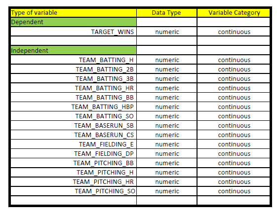

#### 2- Univariate Analysis

At this stage, we explore variables one by one. Method to perform uni-variate analysis will depend on whether the variable type is categorical or continuous. in our case all variables are coutinous. Hence we need to understand the central tendency and spread of each variable. These are measured using various statistical metrics visualization methods:

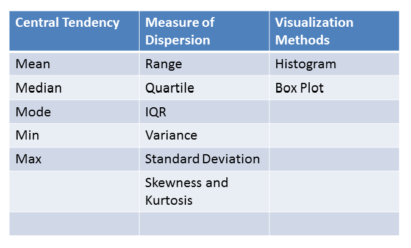

```
##   TARGET_WINS     TEAM_BATTING_H TEAM_BATTING_2B TEAM_BATTING_3B
##  Min.   :  0.00   Min.   : 891   Min.   : 69.0   Min.   :  0.00
##  1st Qu.: 71.00   1st Qu.:1383   1st Qu.:208.0   1st Qu.: 34.00
##  Median : 82.00   Median :1454   Median :238.0   Median : 47.00
##  Mean   : 80.79   Mean   :1469   Mean   :241.2   Mean   : 55.25
##  3rd Qu.: 92.00   3rd Qu.:1537   3rd Qu.:273.0   3rd Qu.: 72.00
##  Max.   :146.00   Max.   :2554   Max.   :458.0   Max.   :223.00
##
##  TEAM_BATTING_HR  TEAM_BATTING_BB TEAM_BATTING_SO  TEAM_BASERUN_SB
##  Min.   :  0.00   Min.   :  0.0   Min.   :   0.0   Min.   :  0.0
##  1st Qu.: 42.00   1st Qu.:451.0   1st Qu.: 548.0   1st Qu.: 66.0
##  Median :102.00   Median :512.0   Median : 750.0   Median :101.0
##  Mean   : 99.61   Mean   :501.6   Mean   : 735.6   Mean   :124.8
##  3rd Qu.:147.00   3rd Qu.:580.0   3rd Qu.: 930.0   3rd Qu.:156.0
##  Max.   :264.00   Max.   :878.0   Max.   :1399.0   Max.   :697.0
##                                   NA's   :102      NA's   :131
##  TEAM_BASERUN_CS TEAM_BATTING_HBP TEAM_PITCHING_H TEAM_PITCHING_HR
##  Min.   :  0.0   Min.   :29.00    Min.   : 1137   Min.   :  0.0
##  1st Qu.: 38.0   1st Qu.:50.50    1st Qu.: 1419   1st Qu.: 50.0
##  Median : 49.0   Median :58.00    Median : 1518   Median :107.0
##  Mean   : 52.8   Mean   :59.36    Mean   : 1779   Mean   :105.7
##  3rd Qu.: 62.0   3rd Qu.:67.00    3rd Qu.: 1682   3rd Qu.:150.0
##  Max.   :201.0   Max.   :95.00    Max.   :30132   Max.   :343.0
##  NA's   :772     NA's   :2085
##  TEAM_PITCHING_BB TEAM_PITCHING_SO  TEAM_FIELDING_E  TEAM_FIELDING_DP
##  Min.   :   0.0   Min.   :    0.0   Min.   :  65.0   Min.   : 52.0
##  1st Qu.: 476.0   1st Qu.:  615.0   1st Qu.: 127.0   1st Qu.:131.0
##  Median : 536.5   Median :  813.5   Median : 159.0   Median :149.0
##  Mean   : 553.0   Mean   :  817.7   Mean   : 246.5   Mean   :146.4
##  3rd Qu.: 611.0   3rd Qu.:  968.0   3rd Qu.: 249.2   3rd Qu.:164.0
##  Max.   :3645.0   Max.   :19278.0   Max.   :1898.0   Max.   :228.0
##                   NA's   :102                        NA's   :286
```

#### 3- Bi-variate Analysis

Bi-variate Analysis finds out the relationship between two variables. Here, we look for association and disassociation between variables at a pre-defined significance level.  
In our case we have only continuous variables we will be doing bi-variate analysis between two continuous variables. We will use scatter plot and find out the relationship between two variables: We are looking to find the pattern and if the relationship between the variables is linear or non-linear.  
Also we will use the scatter plot to show the strength of the relationship between two variable. To find the strength of the relationship, we use Correlation. Correlation varies between -1 and +1.  
-1: perfect negative linear correlation  
+1:perfect positive linear correlation and  
0: No correlation

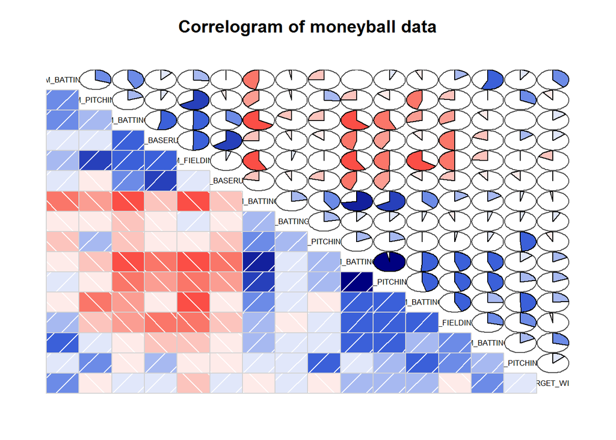

#### 4- Missing values treatment

Missing data in the training data set can reduce the power / fit of a model or can lead to a biased model because we have not analysed the behavior and relationship with other variables correctly. It can lead to wrong prediction or classification.

First let identify the missing data and find the mean for each variable by excluding the missing the data.

|  | Variable | Count.Missing.Values | Mean | Correlation | Theoretical.Impact. |
| --- | --- | --- | --- | --- | --- |
| TARGET_WINS | TARGET_WINS | 0 | 80.79086 | 1.0000000 | Target |
| TEAM_BATTING_H | TEAM_BATTING_H | 0 | 1469.26977 | 0.3887675 | Positive Impact on Wins |
| TEAM_BATTING_2B | TEAM_BATTING_2B | 0 | 241.24692 | 0.2891036 | Positive Impact on Wins |
| TEAM_BATTING_3B | TEAM_BATTING_3B | 0 | 55.25000 | 0.1426084 | Positive Impact on Wins |
| TEAM_BATTING_HR | TEAM_BATTING_HR | 0 | 99.61204 | 0.1761532 | Positive Impact on Wins |
| TEAM_BATTING_BB | TEAM_BATTING_BB | 0 | 501.55888 | 0.2325599 | Positive Impact on Wins |
| TEAM_BATTING_HBP | TEAM_BATTING_HBP | 2085 | 59.35602 | 0.0735042 | Positive Impact on Wins |
| TEAM_BATTING_SO | TEAM_BATTING_SO | 102 | 735.60534 | -0.0317507 | Negative Impact on Wins |
| TEAM_BASERUN_SB | TEAM_BASERUN_SB | 131 | 124.76177 | 0.1351389 | Positive Impact on Wins |
| TEAM_BASERUN_CS | TEAM_BASERUN_CS | 772 | 52.80386 | 0.0224041 | Negative Impact on Wins |
| TEAM_FIELDING_E | TEAM_FIELDING_E | 0 | 246.48067 | -0.1764848 | Negative Impact on Wins |
| TEAM_FIELDING_DP | TEAM_FIELDING_DP | 286 | 146.38794 | -0.0348506 | Positive Impact on Wins |
| TEAM_PITCHING_BB | TEAM_PITCHING_BB | 0 | 553.00791 | 0.1241745 | Negative Impact on Wins |
| TEAM_PITCHING_H | TEAM_PITCHING_H | 0 | 1779.21046 | -0.1099371 | Negative Impact on Wins |
| TEAM_PITCHING_HR | TEAM_PITCHING_HR | 0 | 105.69859 | 0.1890137 | Negative Impact on Wins |
| TEAM_PITCHING_SO | TEAM_PITCHING_SO | 102 | 817.73045 | -0.0784361 | Positive Impact on Wins |

Now that we have identified the count of missing for each variable and the correlation of each variable to our dependent variable TARGET_WINS, we need to decide how to handle the missing the data and which variables to keep based on their correlation.  
We observe that the sign of the correlation roughly matches up with our initial proposed theoretical effect; with BATTING_SO, FIELDING_E, and PITCHING_H indicating a negative correlation. However, there are some instances where the sign conflicts with the proposed theoretical effect for instance PITCHING_HR, and PITCHING_BB have the opposite signs.  
Based on the correlations and missing values, we infer that we abandon imputing values for BATTING_HBP, BATTING_SO, BASERUN_CS, FIELDING_DP due to low correlation to TARGET_WINS.  
However, we are considering the need to impute BASERUN_SB as it has a correlation of 0.1351389 which is relatively acceptable to other correlations. There are few methods to treat missing data such as:

##### 1- Deletion:

Either list wise deletion or pair wise deletion, the deletion method is the simplest method.

##### 2- Mean/ Mode/ Median Imputation:

Imputation is a method to fill in the missing values with estimated ones. The objective is to employ known relationships that can be identified in the valid values of the data set to assist in estimating the missing values. Mean / Mode / Median imputation is one of the most frequently used methods

##### 3- Prediction Model:

This is one of the sophisticated methods for handling missing data. Here, we create a predictive model to estimate values that will substitute the missing data by dividing our data set into two sets. One set with no missing values for the variable and another one with missing values.

##### 4- KNN Imputation:

In this method of imputation, the missing values of an attribute are imputed using the given number of attributes that are most similar to the attribute whose values are missing. The similarity of two attributes is determined using a distance function

### Appendix A

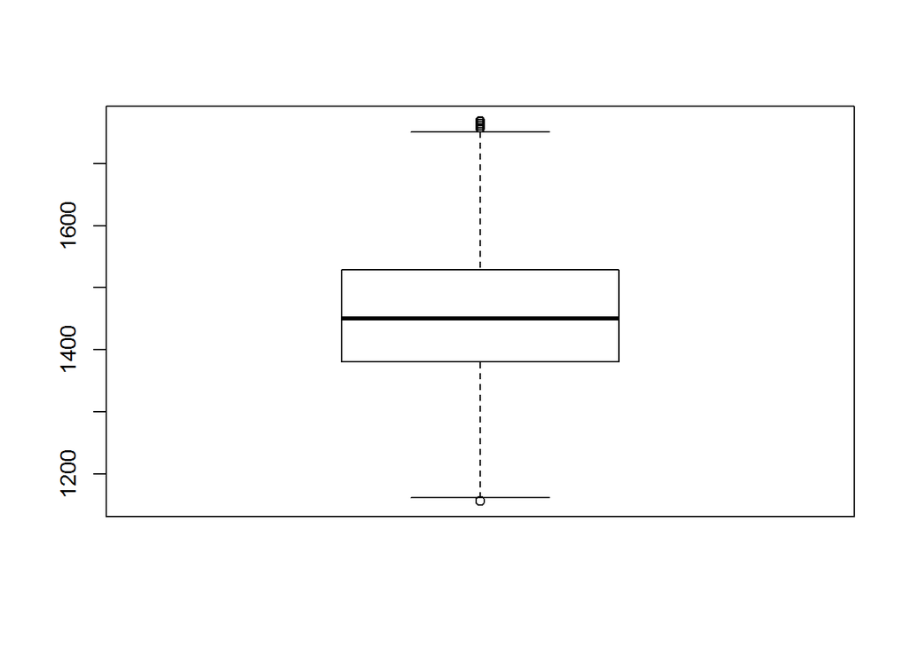

```
## [1] 0.3887675
```

```
## [1] 0.3502207
```

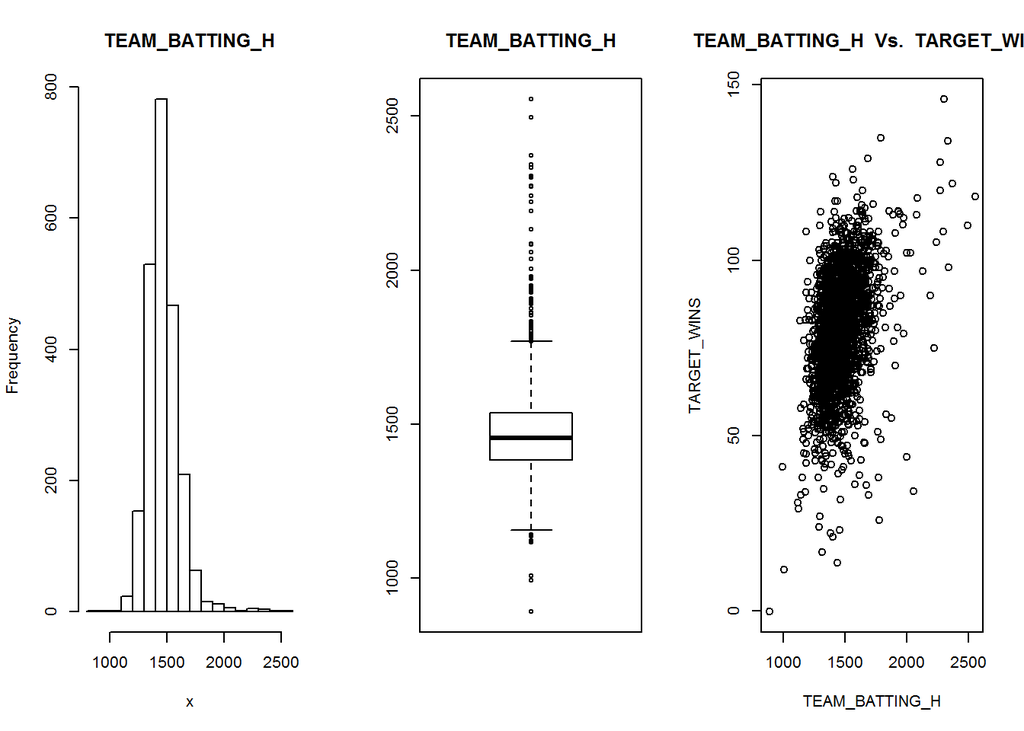

```r
show_charts <- function(x, y, ...) {

    par(mfrow=c(1,3))

    xlabel <- unlist(str_split(deparse(substitute(x)), pattern = "\\$"))[2]
    ylabel <- unlist(str_split(deparse(substitute(y)), pattern = "\\$"))[2]

    hist(x,main=xlabel)
    boxplot(x,main=xlabel)
    plot(jitter(x),jitter(y),xlab=xlabel, ylab=ylabel, main=paste(xlabel, " Vs. ", ylabel ))

}

show_charts(moneyball2$TEAM_BATTING_H,moneyball2$TARGET_WINS)
```

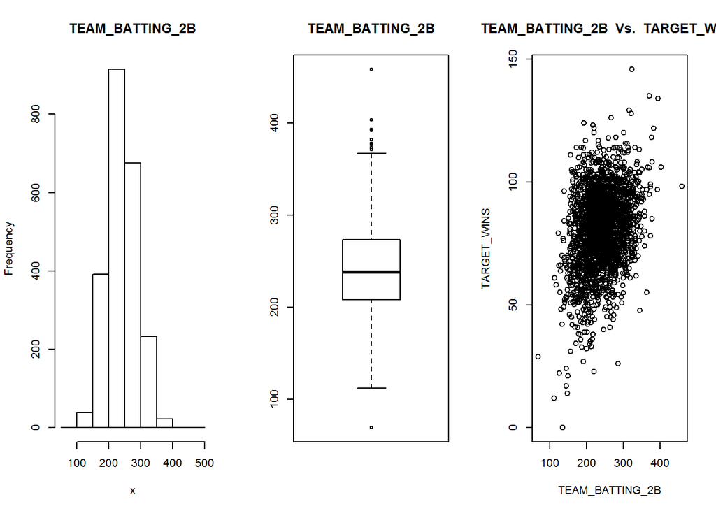

```r
show_charts(moneyball2$TEAM_BATTING_2B,moneyball2$TARGET_WINS)
```

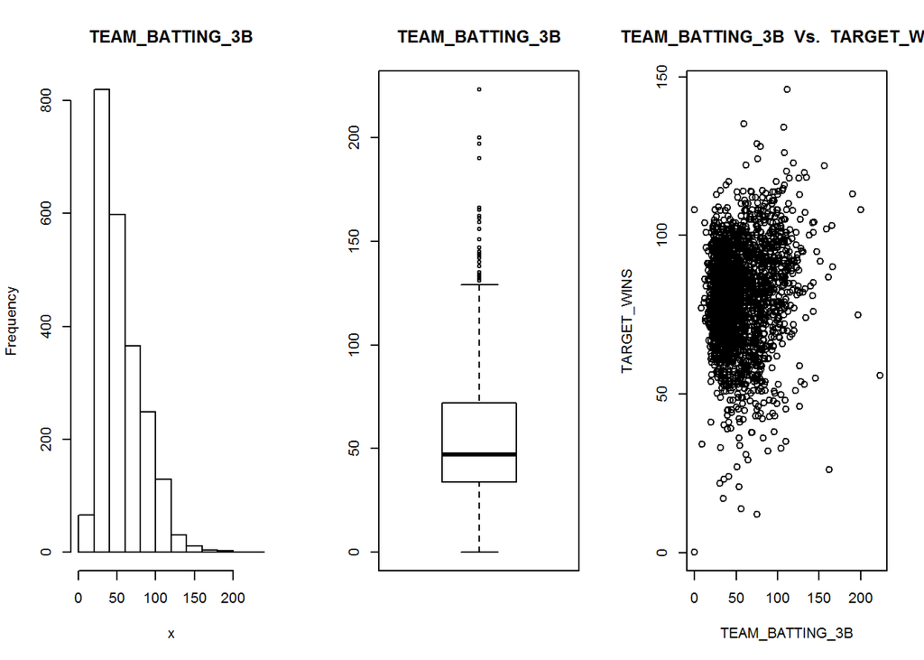

```r
show_charts(moneyball2$TEAM_BATTING_3B,moneyball2$TARGET_WINS)
```

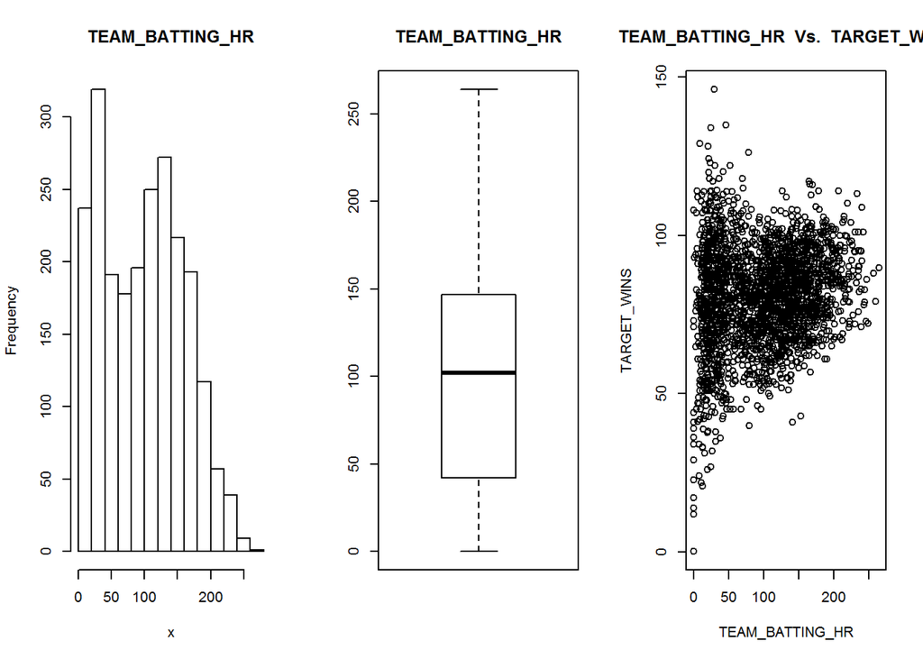

```r
show_charts(moneyball2$TEAM_BATTING_HR,moneyball2$TARGET_WINS)
```

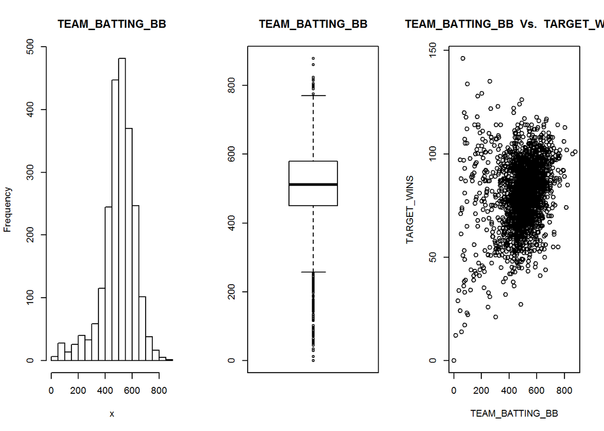

```r
show_charts(moneyball2$TEAM_BATTING_BB,moneyball2$TARGET_WINS)
```

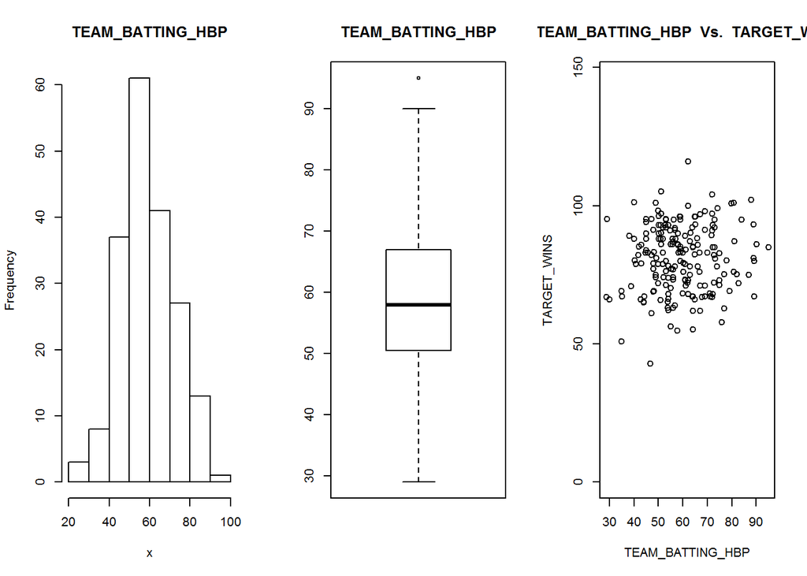

```r
show_charts(moneyball2$TEAM_BATTING_HBP,moneyball2$TARGET_WINS)
```

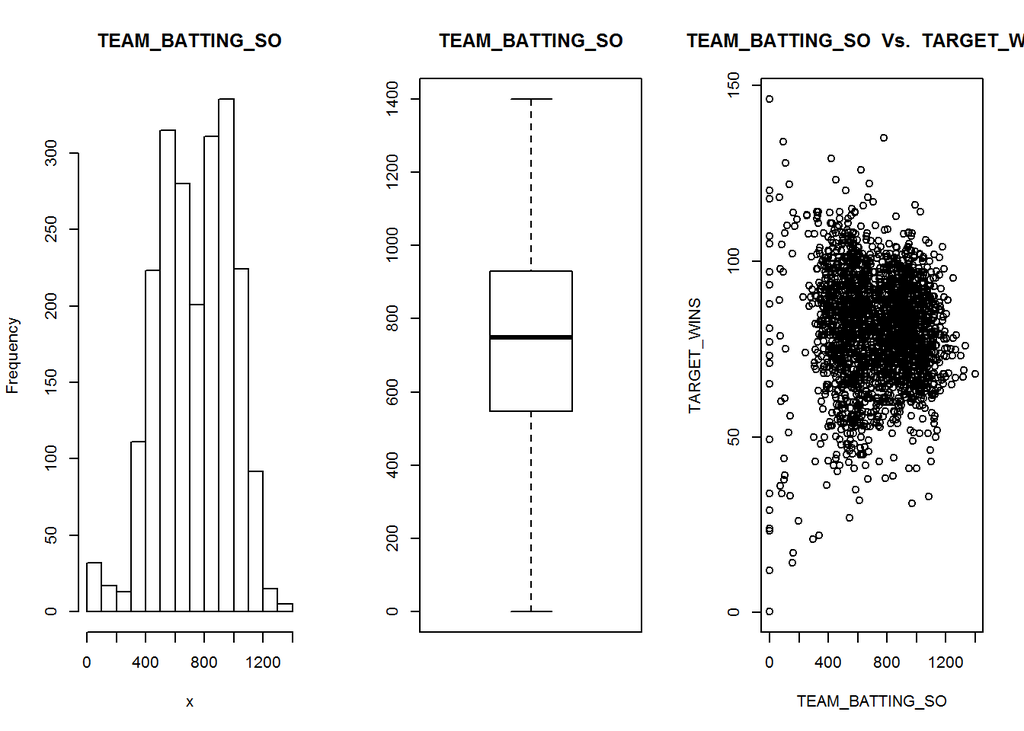

```r
show_charts(moneyball2$TEAM_BATTING_SO,moneyball2$TARGET_WINS)
```

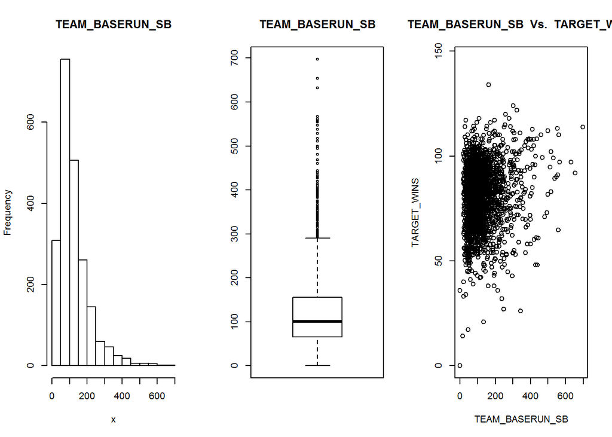

```r
show_charts(moneyball2$TEAM_BASERUN_SB,moneyball2$TARGET_WINS)
```

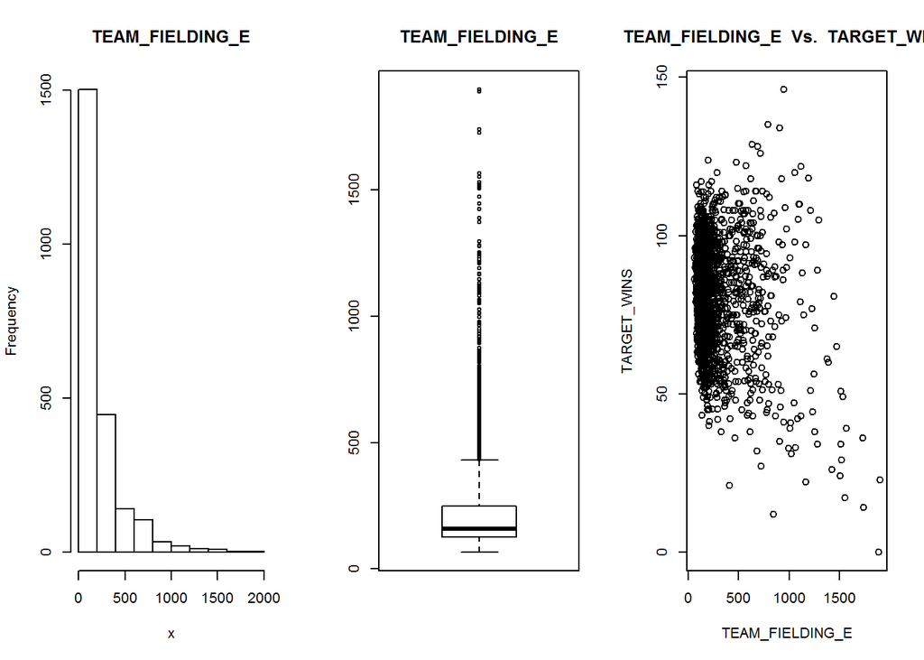

```r
show_charts(moneyball2$TEAM_FIELDING_E,moneyball2$TARGET_WINS)
```

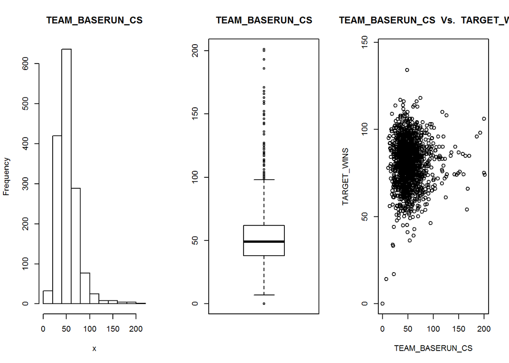

```r
show_charts(moneyball2$TEAM_BASERUN_CS,moneyball2$TARGET_WINS)
```

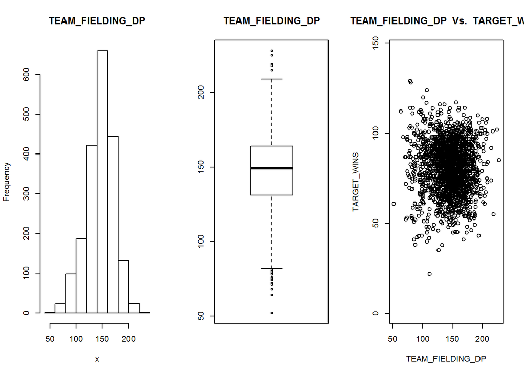

```r
show_charts(moneyball2$TEAM_FIELDING_DP,moneyball2$TARGET_WINS)
```

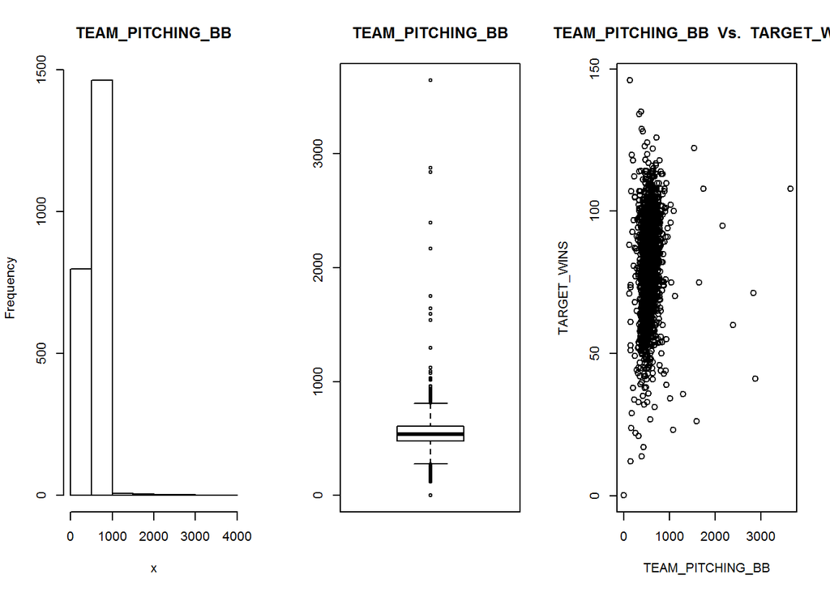

```r
show_charts(moneyball2$TEAM_PITCHING_BB,moneyball2$TARGET_WINS)
```

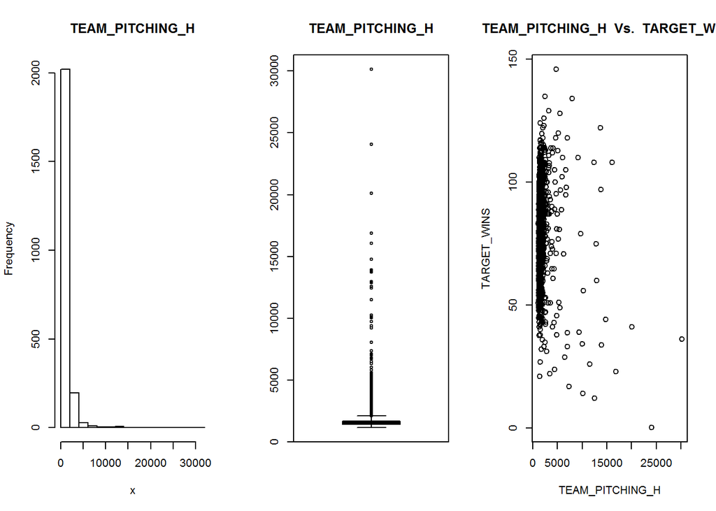

```r
show_charts(moneyball2$TEAM_PITCHING_H,moneyball2$TARGET_WINS)
```

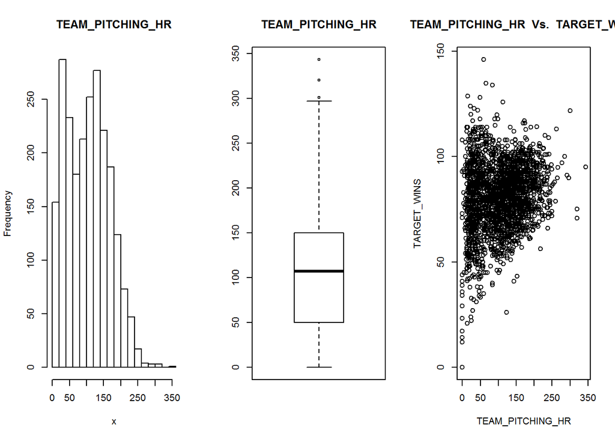

```r
show_charts(moneyball2$TEAM_PITCHING_HR,moneyball2$TARGET_WINS)
```

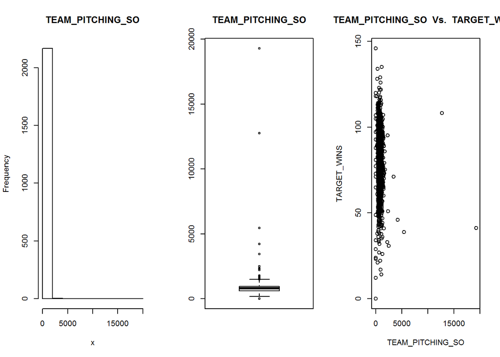

```r
show_charts(moneyball2$TEAM_PITCHING_SO,moneyball2$TARGET_WINS)
```